# Peer Assessment II

# 1 Background

As a statistical consultant working for a real estate investment firm, your task is to develop a model to predict the selling price of a given home in Ames, Iowa. Your employer hopes to use this information to help assess whether the asking price of a house is higher or lower than the true value of the house. If the home is undervalued, it may be a good investment for the firm.

# 2 Training Data and relevant packages

In order to better assess the quality of the model you will produce, the data have been randomly divided into three separate pieces: a training data set, a testing data set, and a validation data set. For now we will load the training data set, the others will be loaded and used later.

```r
load("ames_train.Rdata")
```

Use the code block below to load any necessary packages

```r
library(statsr)
library(dplyr)
library(BAS)
```

```r
library(ggplot2)
```

## 2.1 Part 1 - Exploratory Data Analysis (EDA)

When you first get your data, it’s very tempting to immediately begin fitting models and assessing how they perform. However, before you begin modeling, it’s absolutely essential to explore the structure of the data and the relationships between the variables in the data set.

Do a detailed EDA of the ames_train data set, to learn about the structure of the data and the relationships between the variables in the data set (refer to Introduction to Probability and Data, Week 2, for a reminder about EDA if needed). Your EDA should involve creating and reviewing many plots/graphs and considering the patterns and relationships you see.

After you have explored completely, submit the three graphs/plots that you found most informative during your EDA process, and briefly explain what you learned from each (why you found each informative).

```r
library(GGally)
```

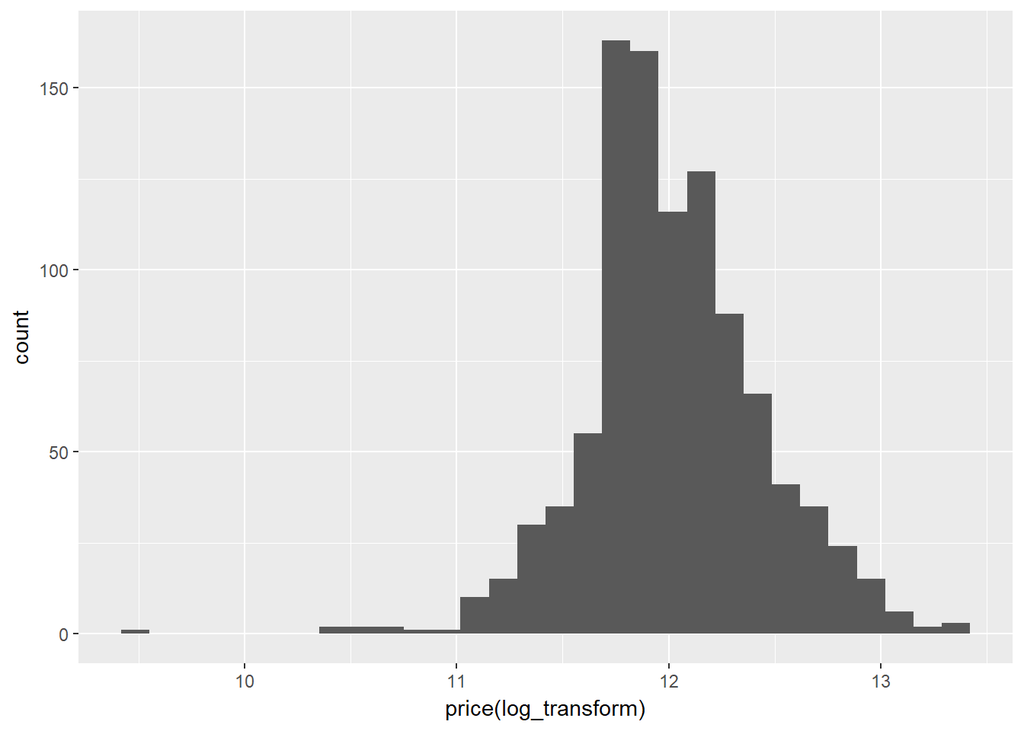

```r
ggplot(ames_train, aes(x =log(price))) +
  geom_histogram()+xlab('price(log_transform)')
```

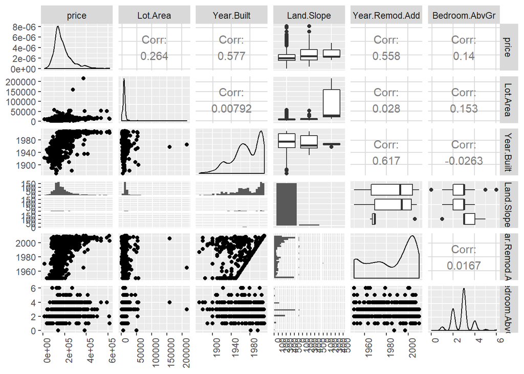

```r
ggpairs(ames_train, columns = c('price','Lot.Area','Year.Built','Land.Slope','Year.Remod.Add','Bedroom.AbvGr'))+ theme(axis.text.x = element_text(angle = 90, hjust =1))
```

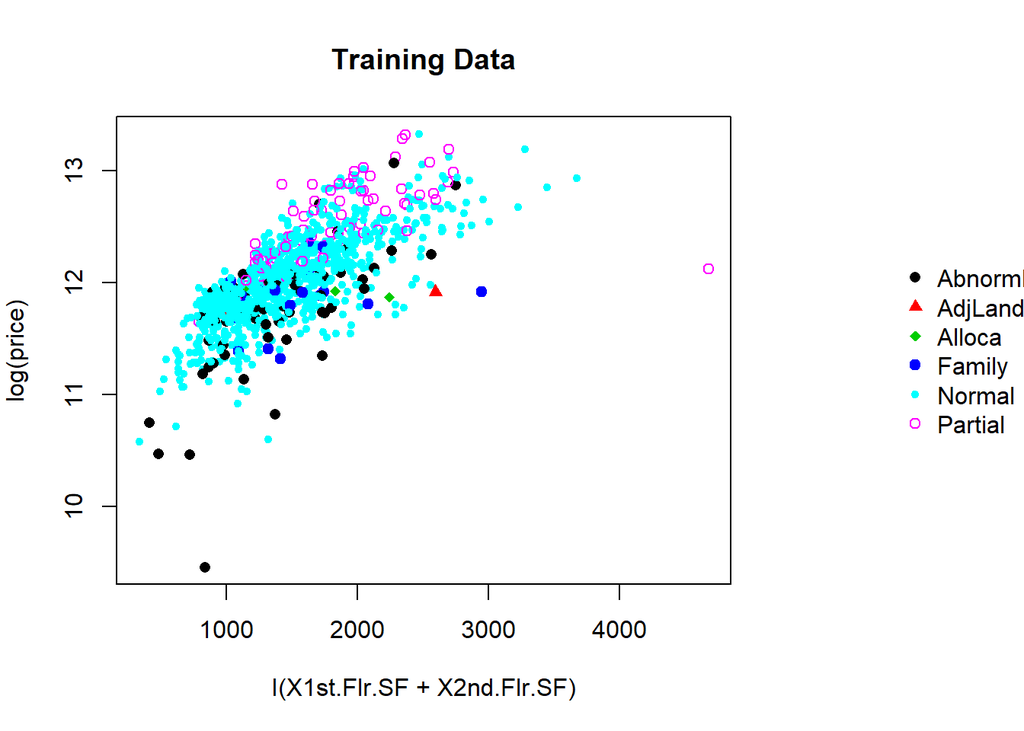

```r
n.Sale.Condition = length(levels(ames_train$Sale.Condition))
par(mar=c(5,4,4,10))
plot(log(price) ~ I(X1st.Flr.SF+X2nd.Flr.SF),
     data=ames_train, col=Sale.Condition,
     pch=as.numeric(Sale.Condition)+15, main="Training Data")
legend(x=,"right", legend=levels(ames_train$Sale.Condition),
       col=1:n.Sale.Condition, pch=15+(1:n.Sale.Condition),
       bty="n", xpd=TRUE, inset=c(-.5,0))
```

The first plot suggests price is not a normal distribution.So we need to transform this data.The log(price) is better.

The second plot suggests some relations between price and explanatory variables,It can give us some advices if we should add this variables to model.

The third plot suggests partial and abnormal sales may have a different generating process altogether. We ensure that the training data only includes houses sold under normal conditions.

```r
ames_train1 <- ames_train %>%
  filter(Sale.Condition == "Normal")
```

## 2.2 Part 2 - Development and assessment of an initial model, following a semi-guided process of analysis

### 2.2.1 Section 2.1 An Initial Model

In building a model, it is often useful to start by creating a simple, intuitive initial model based on the results of the exploratory data analysis. (Note: The goal at this stage is **not** to identify the “best” possible model but rather to choose a reasonable and understandable starting point. Later you will expand and revise this model to create your final model.

Based on your EDA, select *at most* 10 predictor variables from 鈥渁mes_train鈥? and create a linear model for `price` (or a transformed version of price) using those variables. Provide the *R code* and the *summary output table* for your model, a *brief justification* for the variables you have chosen, and a *brief discussion* of the model results in context (focused on the variables that appear to be important predictors and how they relate to sales price).

```r
ml=lm(log(price)~Overall.Qual +Land.Slope +area +
                  Full.Bath + Half.Bath +
                  Bedroom.AbvGr + Year.Built  +
                  Lot.Area +  Central.Air + Overall.Cond,data=ames_train1)
summary(ml)
```

```
##
## Call:
## lm(formula = log(price) ~ Overall.Qual + Land.Slope + area +
##     Full.Bath + Half.Bath + Bedroom.AbvGr + Year.Built + Lot.Area +
##     Central.Air + Overall.Cond, data = ames_train1)
##
## Residuals:
##      Min       1Q   Median       3Q      Max
## -0.73941 -0.07506  0.00084  0.08135  0.52442
##
## Coefficients:
##                 Estimate Std. Error t value Pr(>|t|)
## (Intercept)    1.306e+00  4.859e-01   2.689 0.007315 **
## Overall.Qual   1.010e-01  5.432e-03  18.602  < 2e-16 ***
## Land.SlopeMod  5.949e-02  2.507e-02   2.373 0.017881 *
## Land.SlopeSev -3.769e-01  1.118e-01  -3.372 0.000782 ***
## area           4.367e-04  1.881e-05  23.215  < 2e-16 ***
## Full.Bath     -6.005e-02  1.349e-02  -4.452 9.67e-06 ***
## Half.Bath     -7.459e-02  1.124e-02  -6.636 5.83e-11 ***
## Bedroom.AbvGr -3.419e-02  7.611e-03  -4.493 8.03e-06 ***
## Year.Built     4.676e-03  2.509e-04  18.635  < 2e-16 ***
## Lot.Area       5.865e-06  6.747e-07   8.693  < 2e-16 ***
## Central.AirY   1.389e-01  2.355e-02   5.898 5.37e-09 ***
## Overall.Cond   4.631e-02  4.885e-03   9.480  < 2e-16 ***
## ---
## Signif. codes:  0 '***' 0.001 '**' 0.01 '*' 0.05 '.' 0.1 ' ' 1
##
## Residual standard error: 0.1323 on 822 degrees of freedom
## Multiple R-squared:  0.8815, Adjusted R-squared:  0.8799
## F-statistic:   556 on 11 and 822 DF,  p-value: < 2.2e-16
```

The model i have chosen is not bad,all variables have lower p-value than 5%.

The explanatory variables i have chosen is all importance factors when we buy a house.Overall.Qual,Land.SlopeMod,Land.SlopeMod,area,Year.Built,Lot.Area,Central.AirY,Overall.Cond have positive relations with price,The others is negative. * * *

### 2.2.2 Section 2.2 Model Selection

Now either using `BAS` another stepwise selection procedure choose the “best” model you can, using your initial model as your starting point. Try at least two different model selection methods and compare their results. Do they both arrive at the same model or do they disagree? What do you think this means?

```r
library(MASS)
model.BIC <- stepAIC(ml, k = log(834))
```

```
## Start:  AIC=-3304.81
## log(price) ~ Overall.Qual + Land.Slope + area + Full.Bath + Half.Bath +
##     Bedroom.AbvGr + Year.Built + Lot.Area + Central.Air + Overall.Cond
##
##                 Df Sum of Sq    RSS     AIC
## <none>                       14.395 -3304.8
## - Land.Slope     2    0.3367 14.731 -3299.0
## - Full.Bath      1    0.3471 14.742 -3291.7
## - Bedroom.AbvGr  1    0.3535 14.748 -3291.3
## - Central.Air    1    0.6092 15.004 -3277.0
## - Half.Bath      1    0.7712 15.166 -3268.0
## - Lot.Area       1    1.3234 15.718 -3238.2
## - Overall.Cond   1    1.5736 15.968 -3225.0
## - Overall.Qual   1    6.0597 20.454 -3018.5
## - Year.Built     1    6.0814 20.476 -3017.6
## - area           1    9.4376 23.832 -2891.0
```

```r
model.p <- ml
```

We have chosen two model selection methods.First is BIC method and second is based on p-value.The two models come to same outcome which means we have come to the best model in the variables we have chosen. * * *

### 2.2.3 Section 2.3 Initial Model Residuals

One way to assess the performance of a model is to examine the model’s residuals. In the space below, create a residual plot for your preferred model from above and use it to assess whether your model appears to fit the data well. Comment on any interesting structure in the residual plot (trend, outliers, etc.) and briefly discuss potential implications it may have for your model and inference / prediction you might produce.

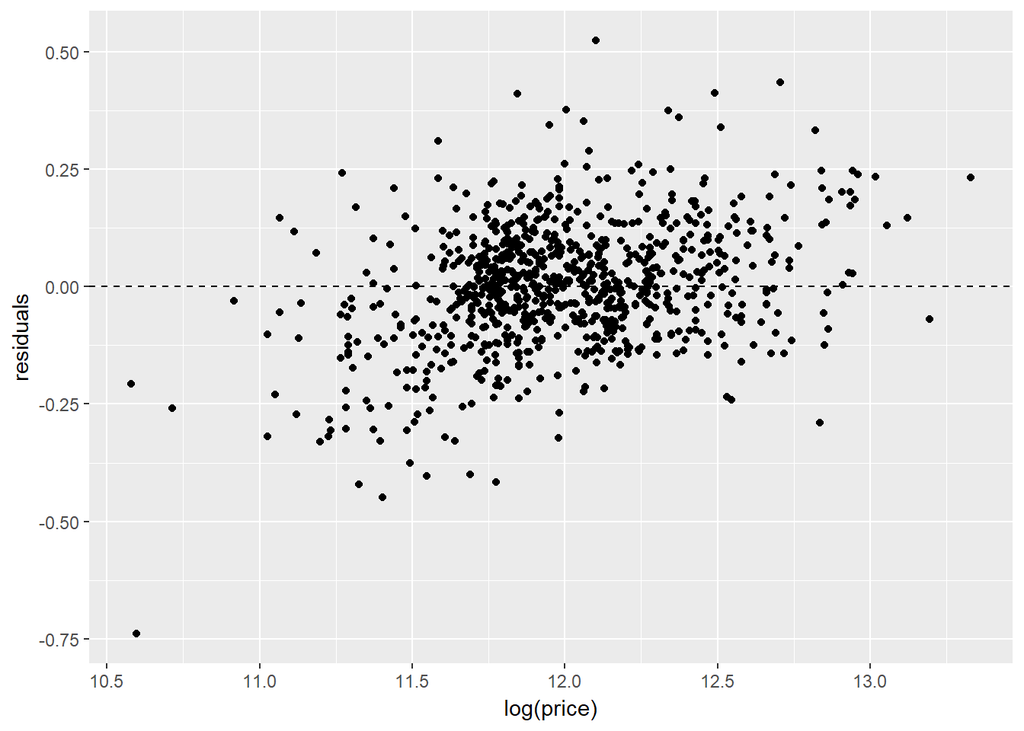

```r
ggplot(data = ames_train1, aes(x = log(price), y =ml$residuals)) +
  geom_point() +
  geom_hline(yintercept = 0, linetype = "dashed")+ylab('residuals')
```

My model do not fit the data very well.It is not always around 0-aix and has tilted trend.

The trend tells us we need to transform some of the variables to get a better model. * * *

### 2.2.4 Section 2.4 Initial Model RMSE

You can calculate it directly based on the model output. Be specific about the units of your RMSE (depending on whether you transformed your response variable). The value you report will be more meaningful if it is in the original units (dollars).

```r
predict.p <- exp(predict(model.p, ames_train1))

# Extract Residuals
resid.p <- ames_train1$price - predict.p

# Calculate RMSE
rmse.p <- sqrt(mean(resid.p^2))
rmse.p
```

```
## [1] 24077.14
```

The RMSE involves taking the square root of the mean of the squared residuals,This model output is log(price),so we need exp to transfer log(price) to normal price.The final outcome is 24077.14. * * *

### 2.2.5 Section 2.5 Overfitting

The process of building a model generally involves starting with an initial model (as you have done above), identifying its shortcomings, and adapting the model accordingly. This process may be repeated several times until the model fits the data reasonably well. However, the model may do well on training data but perform poorly out-of-sample (meaning, on a dataset other than the original training data) because the model is overly-tuned to specifically fit the training data. This is called 鈥渙verfitting.鈥? To determine whether overfitting is occurring on a model, compare the performance of a model on both in-sample and out-of-sample data sets. To look at performance of your initial model on out-of-sample data, you will use the data set `ames_test`.

```r
load("ames_test.Rdata")
```

Use your model from above to generate predictions for the housing prices in the test data set. Are the predictions significantly more accurate (compared to the actual sales prices) for the training data than the test data? Why or why not? Briefly explain how you determined that (what steps or processes did you use)?

```r
predict.p.test <- exp(predict(model.p, ames_test))

# Extract Residuals
resid.p.test <- ames_test$price - predict.p.test

# Calculate RMSE
rmse.p.test <- sqrt(mean(resid.p.test^2))
rmse.p.test
```

```
## [1] 25401.55
```

```r
predict.p.train.c <- exp(predict(model.p, ames_train1, interval = "prediction"))

# Calculate proportion of observations that fall within prediction intervals
coverage.p.train <- mean(ames_train1$price > predict.p.train.c[,"lwr"] &
                            ames_train1$price < predict.p.train.c[,"upr"])
coverage.p.train
```

```
## [1] 0.9556355
```

```r
predict.p.test.c <- exp(predict(model.p, ames_test, interval = "prediction"))

# Calculate proportion of observations that fall within prediction intervals
coverage.p.test <- mean(ames_test$price > predict.p.test.c[,"lwr"] &
                            ames_test$price < predict.p.test.c[,"upr"])
coverage.p.test
```

```
## [1] 0.9485924
```

Here we use two methods to assess model:RMSE and coverage probability.The lower the RMSE is ,the better the model become.Coverage probability assess how well a model reflects uncertainty.The higher the .Coverage probability is ,the better the model become.

**Note to the learner:** If in real-life practice this out-of-sample analysis shows evidence that the training data fits your model a lot better than the test data, it is probably a good idea to go back and revise the model (usually by simplifying the model) to reduce this overfitting. For simplicity, we do not ask you to do this on the assignment, however.

## 2.3 Part 3 Development of a Final Model

Now that you have developed an initial model to use as a baseline, create a final model with *at most* 20 variables to predict housing prices in Ames, IA, selecting from the full array of variables in the dataset and using any of the tools that we introduced in this specialization.

Carefully document the process that you used to come up with your final model, so that you can answer the questions below.

### 2.3.1 Section 3.1 Final Model

Provide the summary table for your model.

```r
model.full <- lm(log(price) ~ Overall.Qual + log(Garage.Area + 1) +
                  log(Total.Bsmt.SF + 1) + Garage.Cars + log(area) +
                  Full.Bath + Half.Bath +
                  Bedroom.AbvGr + Year.Built + log(X1st.Flr.SF) +
                  log(X2nd.Flr.SF + 1) +
                  log(Lot.Area) +  Central.Air + Overall.Cond,
                 data = ames_train1)
summary(model.full)
```

```
##
## Call:
## lm(formula = log(price) ~ Overall.Qual + log(Garage.Area + 1) +
##     log(Total.Bsmt.SF + 1) + Garage.Cars + log(area) + Full.Bath +
##     Half.Bath + Bedroom.AbvGr + Year.Built + log(X1st.Flr.SF) +
##     log(X2nd.Flr.SF + 1) + log(Lot.Area) + Central.Air + Overall.Cond,
##     data = ames_train1)
##
## Residuals:
##      Min       1Q   Median       3Q      Max
## -0.75068 -0.06435 -0.00346  0.07309  0.41449
##
## Coefficients:
##                         Estimate Std. Error t value Pr(>|t|)
## (Intercept)            -1.378113   0.534845  -2.577 0.010150 *
## Overall.Qual            0.087182   0.005062  17.222  < 2e-16 ***
## log(Garage.Area + 1)   -0.007166   0.004676  -1.533 0.125746
## log(Total.Bsmt.SF + 1)  0.025003   0.004046   6.180 1.01e-09 ***
## Garage.Cars             0.049305   0.009772   5.046 5.57e-07 ***
## log(area)               0.477058   0.058831   8.109 1.86e-15 ***
## Full.Bath              -0.007247   0.012576  -0.576 0.564603
## Half.Bath               0.004738   0.012200   0.388 0.697879
## Bedroom.AbvGr          -0.041600   0.006946  -5.989 3.15e-09 ***
## Year.Built              0.003654   0.000242  15.099  < 2e-16 ***
## log(X1st.Flr.SF)        0.096679   0.051153   1.890 0.059114 .
## log(X2nd.Flr.SF + 1)   -0.003947   0.004841  -0.815 0.415052
## log(Lot.Area)           0.119575   0.009471  12.625  < 2e-16 ***
## Central.AirY            0.076803   0.021879   3.510 0.000472 ***
## Overall.Cond            0.052960   0.004381  12.088  < 2e-16 ***
## ---
## Signif. codes:  0 '***' 0.001 '**' 0.01 '*' 0.05 '.' 0.1 ' ' 1
##
## Residual standard error: 0.118 on 819 degrees of freedom
## Multiple R-squared:  0.9061, Adjusted R-squared:  0.9045
## F-statistic: 564.8 on 14 and 819 DF,  p-value: < 2.2e-16
```

I chosen 14 variables as explanatory data. * * *

### 2.3.2 Section 3.2 Transformation

Did you decide to transform any variables? Why or why not? Explain in a few sentences.

```r
model.full1 <- lm(log(price) ~log(area),
                 data = ames_train1)
summary(model.full1)
```

```
##
## Call:
## lm(formula = log(price) ~ log(area), data = ames_train1)
##
## Residuals:
##      Min       1Q   Median       3Q      Max
## -1.36369 -0.12269  0.02005  0.14587  0.82373
##
## Coefficients:
##             Estimate Std. Error t value Pr(>|t|)
## (Intercept)  5.73138    0.18711   30.63   <2e-16 ***
## log(area)    0.86716    0.02587   33.52   <2e-16 ***
## ---
## Signif. codes:  0 '***' 0.001 '**' 0.01 '*' 0.05 '.' 0.1 ' ' 1
##
## Residual standard error: 0.2493 on 832 degrees of freedom
## Multiple R-squared:  0.5745, Adjusted R-squared:  0.574
## F-statistic:  1123 on 1 and 832 DF,  p-value: < 2.2e-16
```

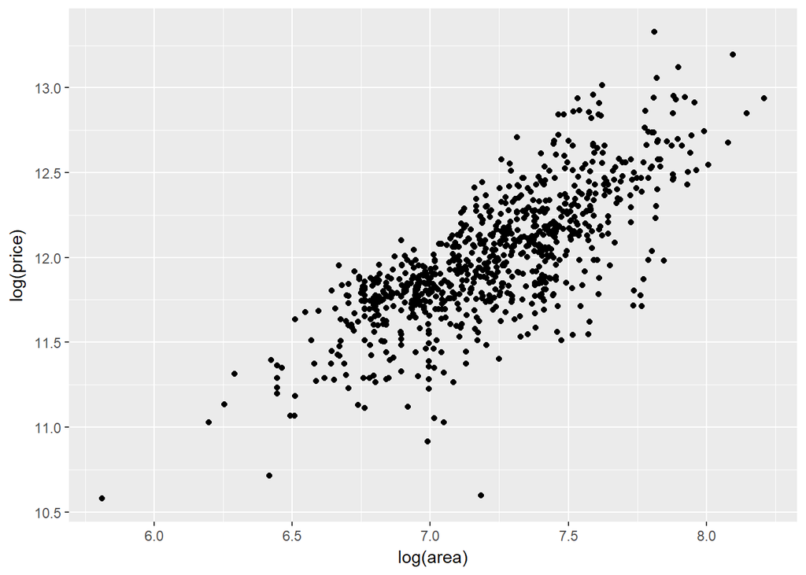

```r
ggplot(data = ames_train1, aes(x = log(area), y =log(price) )) +
  geom_point()
```

```r
model.full2 <- lm(log(price) ~ area ,

                 data = ames_train1)
summary(model.full2)
```

```
##
## Call:
## lm(formula = log(price) ~ area, data = ames_train1)
##
## Residuals:
##      Min       1Q   Median       3Q      Max
## -1.32202 -0.13487  0.02469  0.14897  0.74182
##
## Coefficients:
##              Estimate Std. Error t value Pr(>|t|)
## (Intercept) 1.115e+01  2.744e-02  406.55   <2e-16 ***
## area        5.801e-04  1.792e-05   32.37   <2e-16 ***
## ---
## Signif. codes:  0 '***' 0.001 '**' 0.01 '*' 0.05 '.' 0.1 ' ' 1
##
## Residual standard error: 0.2542 on 832 degrees of freedom
## Multiple R-squared:  0.5574, Adjusted R-squared:  0.5569
## F-statistic:  1048 on 1 and 832 DF,  p-value: < 2.2e-16
```

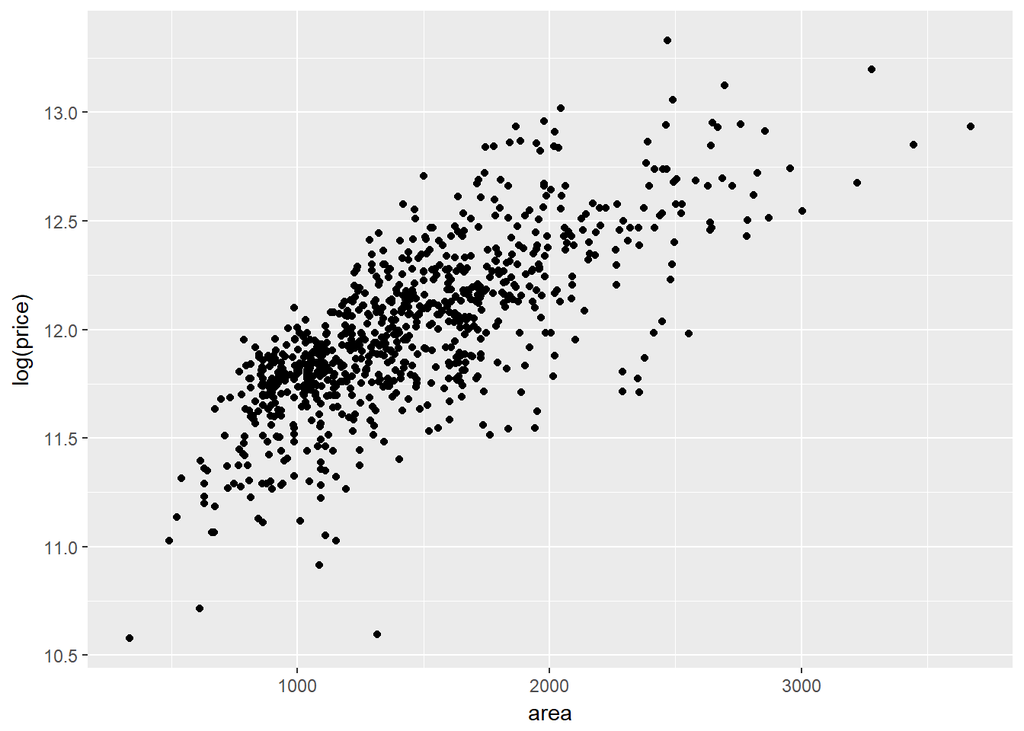

```r
ggplot(data = ames_train1, aes(x = area, y =log(price))) +
  geom_point()
```

In the final model,we transformed Total.BSMT.SF,area,garage.area,lot.area,xlst.flr.sf and x2nd.flr.sf.

As example of area above, transform these variables attained more linear outcome with price .The most importantly transform this variables get higher adjusted R-squared: 0.574 higher than 0.556. * * *

### 2.3.3 Section 3.3 Variable Interaction

Did you decide to include any variable interactions? Why or why not? Explain in a few sentences.

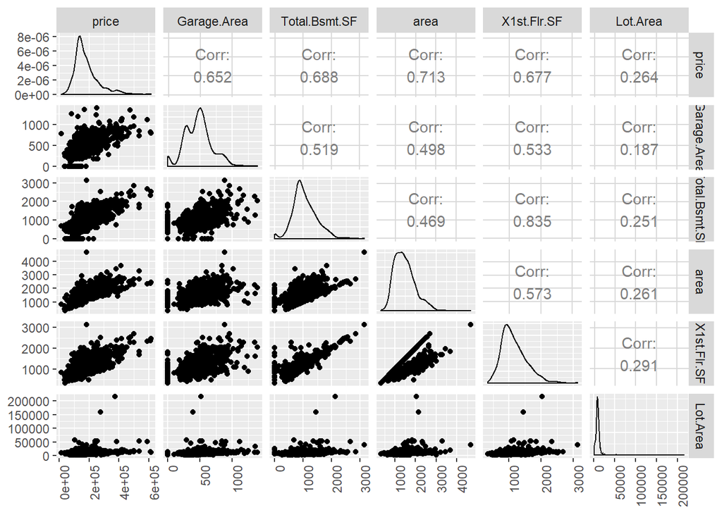

```r
ggpairs(ames_train, columns = c('price','Garage.Area','Total.Bsmt.SF','area','X1st.Flr.SF','Lot.Area'))+ theme(axis.text.x = element_text(angle = 90, hjust =1))
```

This do has interactions.But because we dont have selected model,some variables seem to eliminate from full model.So here i decide not to include any variable interactions. * * *

### 2.3.4 Section 3.4 Variable Selection

What method did you use to select the variables you included? Why did you select the method you used? Explain in a few sentences.

```r
model.BIC <- stepAIC(model.full, k = log(834))
```

```
## Start:  AIC=-3478.96
## log(price) ~ Overall.Qual + log(Garage.Area + 1) + log(Total.Bsmt.SF +
##     1) + Garage.Cars + log(area) + Full.Bath + Half.Bath + Bedroom.AbvGr +
##     Year.Built + log(X1st.Flr.SF) + log(X2nd.Flr.SF + 1) + log(Lot.Area) +
##     Central.Air + Overall.Cond
##
##                          Df Sum of Sq    RSS     AIC
## - Half.Bath               1    0.0021 11.405 -3485.5
## - Full.Bath               1    0.0046 11.407 -3485.4
## - log(X2nd.Flr.SF + 1)    1    0.0093 11.412 -3485.0
## - log(Garage.Area + 1)    1    0.0327 11.435 -3483.3
## - log(X1st.Flr.SF)        1    0.0497 11.452 -3482.1
## <none>                                11.403 -3479.0
## - Central.Air             1    0.1716 11.574 -3473.2
## - Garage.Cars             1    0.3544 11.757 -3460.2
## - Bedroom.AbvGr           1    0.4994 11.902 -3449.9
## - log(Total.Bsmt.SF + 1)  1    0.5318 11.934 -3447.7
## - log(area)               1    0.9155 12.318 -3421.3
## - Overall.Cond            1    2.0344 13.437 -3348.8
## - log(Lot.Area)           1    2.2192 13.622 -3337.4
## - Year.Built              1    3.1742 14.577 -3280.9
## - Overall.Qual            1    4.1292 15.532 -3227.9
##
## Step:  AIC=-3485.54
## log(price) ~ Overall.Qual + log(Garage.Area + 1) + log(Total.Bsmt.SF +
##     1) + Garage.Cars + log(area) + Full.Bath + Bedroom.AbvGr +
##     Year.Built + log(X1st.Flr.SF) + log(X2nd.Flr.SF + 1) + log(Lot.Area) +
##     Central.Air + Overall.Cond
##
##                          Df Sum of Sq    RSS     AIC
## - Full.Bath               1    0.0086 11.413 -3491.6
## - log(X2nd.Flr.SF + 1)    1    0.0089 11.414 -3491.6
## - log(Garage.Area + 1)    1    0.0346 11.439 -3489.7
## - log(X1st.Flr.SF)        1    0.0476 11.452 -3488.8
## <none>                                11.405 -3485.5
## - Central.Air             1    0.1732 11.578 -3479.7
## - Garage.Cars             1    0.3609 11.765 -3466.3
## - Bedroom.AbvGr           1    0.4990 11.904 -3456.5
## - log(Total.Bsmt.SF + 1)  1    0.5329 11.938 -3454.2
## - log(area)               1    1.0089 12.414 -3421.6
```

[output cut: 47 more lines]

```
##     log(area) + Bedroom.AbvGr + Year.Built + log(X1st.Flr.SF) +
##     log(Lot.Area) + Central.Air + Overall.Cond
##
##                          Df Sum of Sq    RSS     AIC
## <none>                                11.454 -3502.1
## - Central.Air             1    0.1577 11.611 -3497.5
## - Garage.Cars             1    0.3751 11.829 -3482.0
## - Bedroom.AbvGr           1    0.5265 11.980 -3471.4
## - log(Total.Bsmt.SF + 1)  1    0.5412 11.995 -3470.4
## - log(X1st.Flr.SF)        1    0.7287 12.182 -3457.4
## - Overall.Cond            1    2.0332 13.487 -3372.6
## - log(Lot.Area)           1    2.2188 13.672 -3361.2
## - Overall.Qual            1    4.1322 15.586 -3251.9
## - Year.Built              1    4.2494 15.703 -3245.7
## - log(area)               1    5.0604 16.514 -3203.7
```

We used BIC method to chose variables.Because it is very convenient to use this method in R ,just one line we can get the outcome,Others need more step. * * *

### 2.3.5 Section 3.5 Model Testing

How did testing the model on out-of-sample data affect whether or how you changed your model? Explain in a few sentences.

```r
predict.BIC.test <- exp(predict(model.BIC, ames_test))

# Extract Residuals
resid.BIC.test <- ames_test$price - predict.BIC.test

# Calculate RMSE
rmse.BIC.test <- sqrt(mean(resid.BIC.test^2))
rmse.BIC.test
```

```
## [1] 24250.02
```

```r
predict.BIC.test <- exp(predict(model.BIC, ames_test, interval = "prediction"))

# Calculate proportion of observations that fall within prediction intervals
coverage.BIC.test <- mean(ames_test$price > predict.BIC.test[,"lwr"] &
                            ames_test$price < predict.BIC.test[,"upr"])
coverage.BIC.test
```

```
## [1] 0.9498164
```

We use RMSE and coverage probability to testing the model on out-of-sample data. The lower the RMSE is ,the better the model become.The higher the Coverage probability is ,the better the model become. * * *

## 2.4 Part 4 Final Model Assessment

### 2.4.1 Section 4.1 Final Model Residual

For your final model, create and briefly interpret an informative plot of the residuals. * * *

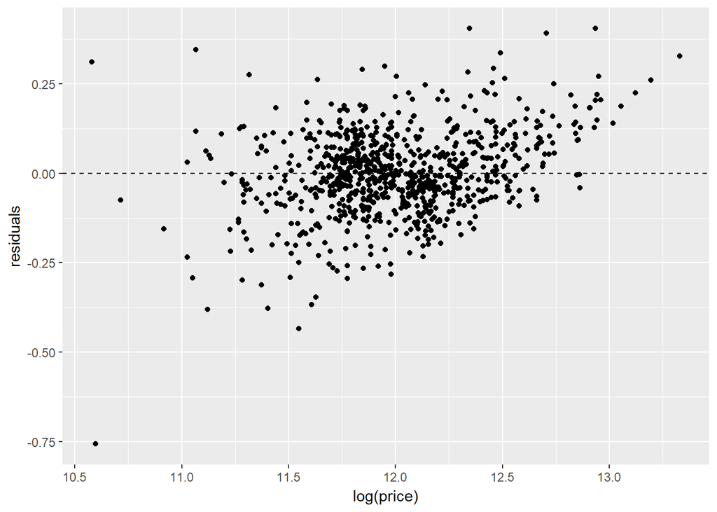

```r
ggplot(data = ames_train1, aes(x = log(price), y =model.BIC$residuals)) +
  geom_point() +
  geom_hline(yintercept = 0, linetype = "dashed")+ylab('residuals')
```

This residual plot also has some outliers and tilted trend,but is better than initial model.

### 2.4.2 Section 4.2 Final Model RMSE

For your final model, calculate and briefly comment on the RMSE.

```r
predict.BIC <- exp(predict(model.BIC, ames_train1))

# Extract Residuals
resid.BIC <- ames_train1$price - predict.BIC

# Calculate RMSE
rmse.BIC <- sqrt(mean(resid.BIC^2))
rmse.BIC
```

```
## [1] 22884.6
```

The RMSE involves taking the square root of the mean of the squared residuals,This model output is log(price),so we need exp to transfer log(price) to normal price.The final outcome is 22884.6 better than initial model 24077.14. * * *

### 2.4.3 Section 4.3 Final Model Evaluation

What are some strengths and weaknesses of your model?

### 2.4.4 Section 4.4 Final Model Validation

Testing your final model on a separate, validation data set is a great way to determine how your model will perform in real-life practice.

You will use the 鈥渁mes_validation鈥? dataset to do some additional assessment of your final model. Discuss your findings, be sure to mention: * What is the RMSE of your final model when applied to the validation data?  
* How does this value compare to that of the training data and/or testing data? * What percentage of the 95% predictive confidence (or credible) intervals contain the true price of the house in the validation data set?  
* From this result, does your final model properly reflect uncertainty?

```r
load("ames_validation.Rdata")
```

```r
predict.BIC.va <- exp(predict(model.BIC, ames_validation))

# Extract Residuals
resid.BIC.va <- ames_validation$price - predict.BIC.va

# Calculate RMSE
rmse.BIC.va <- sqrt(mean(resid.BIC.va^2))
rmse.BIC.va
```

```
## [1] 21814.3
```

```r
predict.BIC.va1 <- exp(predict(model.BIC, ames_validation, interval = "prediction"))

# Calculate proportion of observations that fall within prediction intervals
coverage.BIC.va <- mean(ames_validation$price > predict.BIC.va1[,"lwr"] &
                            ames_validation$price < predict.BIC.va1[,"upr"])
coverage.BIC.va
```

```
## [1] 0.9515072
```

The RMSE of my final model when applied to the validation data is 21814.3.

95.1% intervals contain the true price of the house in the validation data set.

Because 95.1% > 95% so my final model properly reflect uncertainty.

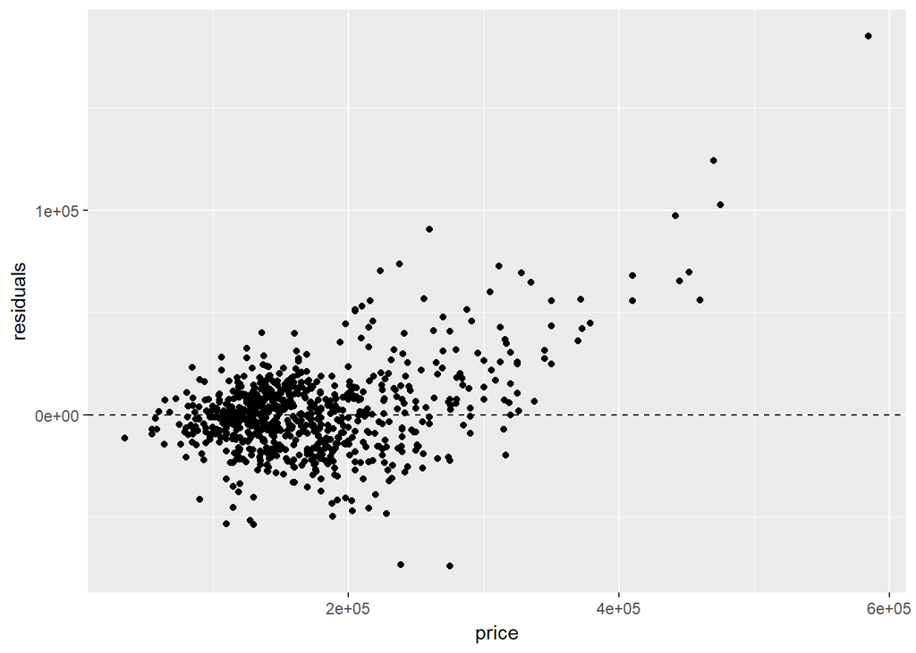

```r
ggplot(data = ames_validation, aes(x = price, y =resid.BIC.va)) +
  geom_point() +
  geom_hline(yintercept = 0, linetype = "dashed")+ylab('residuals')
```

```r
ames_validation%>%mutate(res=resid.BIC.va )%>%arrange(desc(res))
```

```
## # A tibble: 763 x 82
##        PID  area  price MS.SubClass MS.Zoning Lot.Frontage Lot.Area Street
##      <int> <int>  <int>       <int> <fct>            <int>    <int> <fct>
##  1  5.28e8  3500 584500          60 RL                 114    17242 Pave
##  2  5.27e8  2000 470000          20 RL                  90    18261 Pave
##  3  9.02e8  3608 475000          75 RM                  90    22950 Pave
##  4  5.27e8  2234 441929          20 RL                  85    14082 Pave
##  5  9.05e8  1518 260000          30 RL                  85    19550 Pave
##  6  9.09e8  1718 238000          70 RL                  60     7230 Pave
##  7  9.09e8  1954 311500          50 RL                  NA    15660 Pave
##  8  9.03e8  1576 223500          70 RL                 144    21384 Pave
##  9  5.28e8  2296 451950          60 RL                  97    13478 Pave
## 10  9.05e8  2260 328000          60 RL                  80    14000 Pave
## # ... with 753 more rows, and 74 more variables: Alley <fct>,
## #   Lot.Shape <fct>, Land.Contour <fct>, Utilities <fct>,
## #   Lot.Config <fct>, Land.Slope <fct>, Neighborhood <fct>,
## #   Condition.1 <fct>, Condition.2 <fct>, Bldg.Type <fct>,
## #   House.Style <fct>, Overall.Qual <int>, Overall.Cond <int>,
## #   Year.Built <int>, Year.Remod.Add <int>, Roof.Style <fct>,
## #   Roof.Matl <fct>, Exterior.1st <fct>, Exterior.2nd <fct>,
## #   Mas.Vnr.Type <fct>, Mas.Vnr.Area <int>, Exter.Qual <fct>,
## #   Exter.Cond <fct>, Foundation <fct>, Bsmt.Qual <fct>, Bsmt.Cond <fct>,
## #   Bsmt.Exposure <fct>, BsmtFin.Type.1 <fct>, BsmtFin.SF.1 <int>,
## #   BsmtFin.Type.2 <fct>, BsmtFin.SF.2 <int>, Bsmt.Unf.SF <int>,
## #   Total.Bsmt.SF <int>, Heating <fct>, Heating.QC <fct>,
## #   Central.Air <fct>, Electrical <fct>, X1st.Flr.SF <int>,
## #   X2nd.Flr.SF <int>, Low.Qual.Fin.SF <int>, Bsmt.Full.Bath <int>,
## #   Bsmt.Half.Bath <int>, Full.Bath <int>, Half.Bath <int>,
## #   Bedroom.AbvGr <int>, Kitchen.AbvGr <int>, Kitchen.Qual <fct>,
## #   TotRms.AbvGrd <int>, Functional <fct>, Fireplaces <int>,
## #   Fireplace.Qu <fct>, Garage.Type <fct>, Garage.Yr.Blt <int>,
## #   Garage.Finish <fct>, Garage.Cars <int>, Garage.Area <int>,
## #   Garage.Qual <fct>, Garage.Cond <fct>, Paved.Drive <fct>,
## #   Wood.Deck.SF <int>, Open.Porch.SF <int>, Enclosed.Porch <int>,
## #   X3Ssn.Porch <int>, Screen.Porch <int>, Pool.Area <int>, Pool.QC <fct>,
## #   Fence <fct>, Misc.Feature <fct>, Misc.Val <int>, Mo.Sold <int>,
## #   Yr.Sold <int>, Sale.Type <fct>, Sale.Condition <fct>, res <dbl>
```

```r
ames_validation%>%mutate(res=resid.BIC.va )%>%arrange(res)
```

```
## # A tibble: 763 x 82
##        PID  area  price MS.SubClass MS.Zoning Lot.Frontage Lot.Area Street
##      <int> <int>  <int>       <int> <fct>            <int>    <int> <fct>
##  1  5.32e8  2014 275000          20 RL                  NA    15676 Pave
##  2  9.06e8  1800 239000          20 RL                 122    11923 Pave
##  3  9.08e8  1709 130000         160 RM                  24     2522 Pave
##  4  5.35e8  1392 110000          20 RL                 120    13560 Pave
##  5  9.05e8  1689 127500          20 RL                  73     9855 Pave
##  6  5.34e8  1594 188500          20 RL                  80     9547 Pave
##  7  9.16e8  1707 228000          20 RL                  NA    16669 Pave
##  8  5.31e8  1512 203000          20 RL                  76    10141 Pave
##  9  5.27e8  2093 215000          60 RL                  46    20544 Pave
## 10  5.27e8  1474 115000          20 RL                  NA    31220 Pave
## # ... with 753 more rows, and 74 more variables: Alley <fct>,
## #   Lot.Shape <fct>, Land.Contour <fct>, Utilities <fct>,
## #   Lot.Config <fct>, Land.Slope <fct>, Neighborhood <fct>,
## #   Condition.1 <fct>, Condition.2 <fct>, Bldg.Type <fct>,
## #   House.Style <fct>, Overall.Qual <int>, Overall.Cond <int>,
## #   Year.Built <int>, Year.Remod.Add <int>, Roof.Style <fct>,
## #   Roof.Matl <fct>, Exterior.1st <fct>, Exterior.2nd <fct>,
## #   Mas.Vnr.Type <fct>, Mas.Vnr.Area <int>, Exter.Qual <fct>,
## #   Exter.Cond <fct>, Foundation <fct>, Bsmt.Qual <fct>, Bsmt.Cond <fct>,
## #   Bsmt.Exposure <fct>, BsmtFin.Type.1 <fct>, BsmtFin.SF.1 <int>,
## #   BsmtFin.Type.2 <fct>, BsmtFin.SF.2 <int>, Bsmt.Unf.SF <int>,
## #   Total.Bsmt.SF <int>, Heating <fct>, Heating.QC <fct>,
## #   Central.Air <fct>, Electrical <fct>, X1st.Flr.SF <int>,
## #   X2nd.Flr.SF <int>, Low.Qual.Fin.SF <int>, Bsmt.Full.Bath <int>,
## #   Bsmt.Half.Bath <int>, Full.Bath <int>, Half.Bath <int>,
## #   Bedroom.AbvGr <int>, Kitchen.AbvGr <int>, Kitchen.Qual <fct>,
## #   TotRms.AbvGrd <int>, Functional <fct>, Fireplaces <int>,
## #   Fireplace.Qu <fct>, Garage.Type <fct>, Garage.Yr.Blt <int>,
## #   Garage.Finish <fct>, Garage.Cars <int>, Garage.Area <int>,
## #   Garage.Qual <fct>, Garage.Cond <fct>, Paved.Drive <fct>,
## #   Wood.Deck.SF <int>, Open.Porch.SF <int>, Enclosed.Porch <int>,
## #   X3Ssn.Porch <int>, Screen.Porch <int>, Pool.Area <int>, Pool.QC <fct>,
## #   Fence <fct>, Misc.Feature <fct>, Misc.Val <int>, Mo.Sold <int>,
## #   Yr.Sold <int>, Sale.Type <fct>, Sale.Condition <fct>, res <dbl>
```

The residuals is the subtract of real price and predicted price.The data above the line means we predicted a lower priced but real price is high,it is a overvalued house. Ubove the line means we predicted a higher priced but real price is low,it is a undervalued house.

## 2.5 Part 5 Conclusion

Provide a brief summary of your results, and a brief discussion of what you have learned about the data and your model.

In validation data,It has 95.1% coverage probability properly reflect uncertainty.

Importent lessons:1.Adding additional variables to the model doesn’t mean that those variables will enhance model performance.2.Sometimes a transform can get a better model. * * *